# Entrega N° 1 - Grupo 01

# Práctica 1

## Ejercicio 1

Análisis del artículo: “Characterizing mutagenic effects of recombination through a sequencelevel genetic map” (Halldorsson et al, 2019).

### 1. Leer el resumen de investigación (adjunto en este documento). Identificar el tema y el objetivo del trabajo.

Tema: Efectos mutagénicos de la recombinación meiótica utilizando un mapeo genético de alta resolución.

Objetivo: Analizar la asociación de sexo, edad y variantes (epi)genéticas con las apariciones de mutaciones de novo.

### 2. Al final de este documento se agrega una selección de figuras tomadas del artículo. Identificar una figura donde se observe cada uno de los hallazgos resaltados en la sección Results del resumen.

- Frecuencia de cruces complejos según sexo de la progenie: Figura 2A (*Sex specific mutation rate vs Distance from crossover*) y 2E (*Sex specific mutation rate vs Distance from crossover*); que entendemos es la misma figura con otra escala en el eje horizontal. Se encuentra discriminado según entrecruzamiento materno o paterno. Aunque la tasa de entrecruzamiento materno es menor a mayor distancia (entrecruzamiento complejo). Esto no estaría en concordancia con lo propuesto por la autoría.

- Aumento de la tasa de entrecruzamiento con la edad materna: Figura 3A (*Maternal recombination rate vs Mother’s age at birth*). Se observa un aumento en la tasa de recombinación materna al aumentar la edad al nacimiento. Vale aclarar que las unidades de la tasa de recombinación no es clara.

- Aumento del porcentaje de entrecruzamientos complejo con la edad materna: Figura 3B (*Percentage of complex crossover vs Mother’s age at birth*). Se observa un aumento en el porcentaje de entrecruzamientos complejos al aumentar la edad al nacimiento aunque no resulta fácil interpretar las unidades ya que solamente se indican los valores 1 y 2 en el eje *y*.

*- Aumento en los DNM dentro de 1 kb de los cruces, diferenciando por sexo: Figura 2B (Fraction vs Mutation class).*

### 3. Acerca de la figura 2D: describir la distribución de la distancia desde una mutación de novo (DNM) hasta un crossover (CO,) y comparar entre CO maternos y paternos.

La distribución de la distancia de la DNM al CO es asimétrica a la derecha en ambos casos; aunque el CO paterno parecería ser más pronunciado. Esto puede interpretarse como que el CO materno, en promedio, ocurre a una mayor distancia de la DNM.

### 4. Acerca de las figuras 2A y 2E:

#### a. ¿Qué sucede con la tasa de (DNM) a medida que aumenta la distancia desde un crossover (CO)?

Para ambos sexos, disminuye la tasa.

#### b. ¿Se diferencia la tasa de DNM según se encuentren alrededor de un CO materno o paterno?

Habría que realizar un análisis estadístico apropiado, pero parecería hacer diferencia ya que el valor medio del CO materno se encuentra, en todos los casos, por debajo del CO paterno.

#### c. ¿Cómo se compara la tasa de DNM en cercanías de CO frente a la tasa global de DNM en el genoma?

En cercanías de la DNM al CO, [0-1000], tanto el CO materno como paterno se encuentran por encima de la tasa GW,

#### d. ¿Qué diferencia hay entre las figuras 2A y 2E?

Parecería ser que la única diferencia es la construcción de los intervalos de las distancias de la DNM al CO.

#### e. ¿Qué representan los puntos? ¿Qué representan las líneas? ¿Hay mayor variabilidad en la tasa de DNM a mayor distancia del CO? Observar y comentar la escala elegida.

Interpretamos que los puntos representan los valores medios o centrales de la tasa de mutación correspondiente a cada intervalo de distancia al CO. Los segmentos podrían representar la variabilidad.

### 5. Acerca de la figura 2C: ¿cuáles son las tres variables cualitativas representadas?

La figura 2 C presenta las variables categóricas “sexo del progenitor”, “orientación del entrecruzamiento” y “tipo de mutación”.

### 6. Acerca de la figura 2B:

#### a. Mencionar un tipo de mutación que ocurre con frecuencia similar, ya sea en todo el genoma (materno o paterno) o cerca de un CO (materno o paterno).

Las mutaciones que presentan, en general, una fracción similar son las genómicas. C>G, CpG>TpG, Indel y T>A.

#### b. Mencionar un tipo de mutación que ocurre con mayor frecuencia en cercanía a un CO materno.

C>T

# Práctica 2

## Ejercicio 5

La concentración sérica de 25-hidroxivitamina D (25-OHD) es utilizada como indicador del estado nutricional de Vitamina D (VD). El método más utilizado para medirla es el RIA. El desarrollo reciente de métodos automatizados no radiactivos facilitaría la práctica diaria de laboratorio y el diagnóstico de necesidad de suplementación.

Objetivos: Comparar los datos de 25-OHD obtenidos usando un RIA y un método de quimioluminiscencia (QLIA) automatizado disponible en nuestro medio.

Materiales y métodos: Concentraciones de 25-OHD se midieron en suero de 16 pacientes. Las mediciones de 25-OHD (ng/mL) se realizaron con un RIA y un QLIA automatizado (LIAISON), ambos DiaSorin. En el archivo “vitD.txt” se presentan las determinaciones obtenidas.

¿Existe evidencia para concluir que ambos métodos permiten determinar el mismo valor promedio de 25 hidroxivitamina D (250HD)?

### a) Variables, factor y tipo de muestras

• Variable aleatoria: concentración de 25-OHD (ng/mL).  
• Factor en estudio: Método (dos niveles: RIA y QLIA).  
• Las mediciones están pareadas ⇒ muestras dependientes.

### b) Descripción de los datos

```
## [1] "RIA"
```

```
##    Min. 1st Qu.  Median    Mean 3rd Qu.    Max.
##   13.20   14.38   15.15   15.36   16.25   18.80
```

```
## [1] "sd"
```

```
## [1] 1.519197
```

```
## [1] "QLIA"
```

```
##    Min. 1st Qu.  Median    Mean 3rd Qu.    Max.
##   13.60   14.72   16.00   16.00   17.12   19.20
```

```
## [1] "sd"
```

```
## [1] 1.655697
```

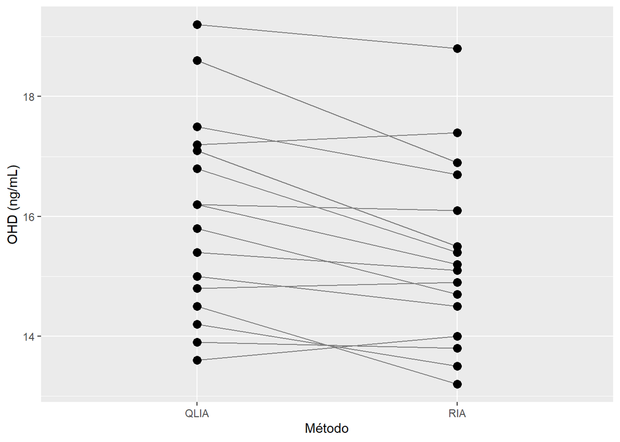

El gráfico de líneas (una línea por paciente) muestra que la mayoría de los puntos de QLIA están por encima de los de RIA.

### c) Parámetro e hipótesis

Definimos la diferencia por paciente  
d = RIA – QLIA.

Parámetro: μ<sub>d</sub> = media poblacional de la diferencia.

Hipótesis bilateral  
H₀ : μ<sub>d</sub>= 0 (ambos métodos dan, en promedio, el mismo valor)  
H₁ : μ<sub>d</sub> ≠ 0

α = 0,05.

### d) Comprobación de supuestos

```
##
##  Shapiro-Wilk normality test
##
## data:  vitD$d
## W = 0.96155, p-value = 0.69
```

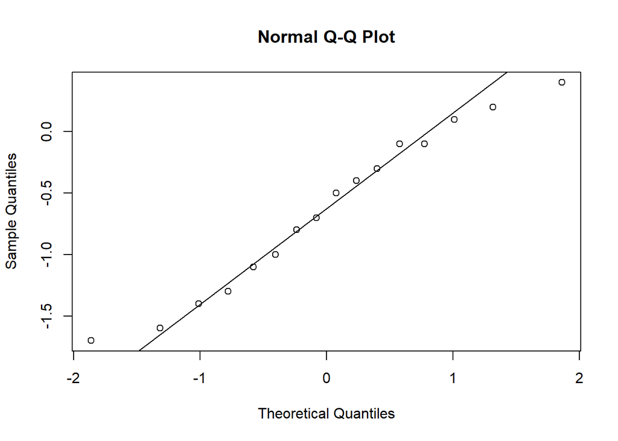

Test de shapiro: p = 0.69 → no se rechaza la normalidad; el gráfico QQ luce aceptable.  
⇒ Se cumplen los supuestos para realizar el test de hipótesis.

Se emplea un test-t para muestras pareadas

### e) Prueba de hipótesis y conclusión

```
##
##  Paired t-test
##
## data:  vitD$RIA and vitD$QLIA
## t = -3.8999, df = 15, p-value = 0.001421
## alternative hypothesis: true mean difference is not equal to 0
## 95 percent confidence interval:
##  -0.9955838 -0.2919162
## sample estimates:
## mean difference
##        -0.64375
```

Interpretación

Conclusión  
Con un nivel de significación del 5% y en base a la evidencia muestral, se concluye que los dos métodos analizados NO determinan, en promedio, la misma concentración de 25-hidroxivitamina D. El método RIA produce en promedio valores más bajos que el método automatizado de quimioluminiscencia (QLIA).

# Práctica 3

## Ejercicio 4

Se realizó un experimento con el objetivo de evaluar el efecto que tienen la temperatura y el porcentaje de un compuesto sobre el rendimiento de una reacción química. Los tratamientos estudiados fueron las combinaciones de tres temperaturas y tres porcentajes del compuesto. Se realizaron un total de 18 reacciones utilizando un diseño balanceado, asignando al azar el orden en que se probaron los tratamientos. La respuesta medida fue la diferencia entre el rendimiento teórico de la reacción y el observado. Los valores observados se encuentran en el archivo “rendimiento.txt”. El objetivo final del problema es minimizar la diferencia entre el rendimiento teórico de la reacción y el observado.

1. Realice un breve análisis descriptivo de los datos y describa brevemente lo observado en el mismo.
2. Ajuste el modelo lineal apropiado para el diseño experimental y evalúe la existencia de efecto interacción entre temperatura y porcentaje del compuesto. ¿Puede ajustarse un modelo lineal “simplificado”?
3. Verifique el cumplimiento de supuestos del modelo lineal elegido según la respuesta del punto anterior.
4. Evalúe la existencia de efectos no lineales en los factores cuantitativos.
5. Busque las condiciones que minimizan la diferencia entre el rendimiento teórico de la reacción y el observado y estime la respuesta media para dichas condiciones.

### a) Análisis descriptivo del conjunto de datos

Variable aleatoria Y: Rendimiento de la reacción química (diferencia entre el rendimiento teórico y el observado). Es una variable cuantitativa continua.

Factores en estudio:

- Temperatura: cuantitativa

Niveles: 50, 75 y 100 ºC

- Compuesto B: cuantitativa

Niveles: 40, 60 y 80%.

No hay factor de bloqueo.

| Temperatura | Porcentaje | Media | SD | Mediana | Rango |
| --- | --- | --- | --- | --- | --- |
| 100 | 40 | 15.0 | 1.4142136 | 15.0 | 2 |
| 100 | 60 | 19.5 | 2.1213203 | 19.5 | 3 |
| 100 | 80 | 24.0 | 1.4142136 | 24.0 | 2 |
| 50 | 40 | 12.0 | 1.4142136 | 12.0 | 2 |
| 50 | 60 | 15.5 | 0.7071068 | 15.5 | 1 |
| 50 | 80 | 17.0 | 1.4142136 | 17.0 | 2 |
| 75 | 40 | 10.5 | 2.1213203 | 10.5 | 3 |
| 75 | 60 | 13.5 | 0.7071068 | 13.5 | 1 |
| 75 | 80 | 16.0 | 1.4142136 | 16.0 | 2 |

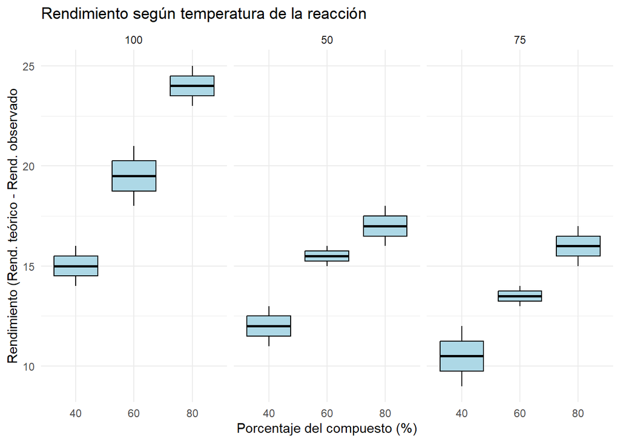

### b) Ajuste del modelo lineal

Evaluación de la interacción entre factores

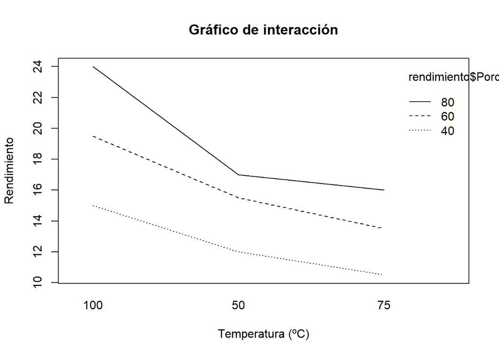

Se observa una pendiente más pronunciada para el rendimiento de la reacción en el cambio de temperatura entre 50 y 75ºC para un porcentaje de B=60%.

```
##                        Df Sum Sq Mean Sq F value   Pr(>F)
## Temperatura             2 124.11   62.06   27.93 0.000138 ***
## Porcentaje              2 127.44   63.72   28.68 0.000125 ***
## Temperatura:Porcentaje  4  10.22    2.56    1.15 0.393479
## Residuals               9  20.00    2.22
## ---
## Signif. codes:  0 '***' 0.001 '**' 0.01 '*' 0.05 '.' 0.1 ' ' 1
```

Analizando detalladamente la salida del cuadro ANOVA, encontramos que no es significativa la interacción entre las variables *Temperatura* y *Porcentaje*. Por lo que podemos resumir el modelo a uno sin interacción.

```
##             Df Sum Sq Mean Sq F value   Pr(>F)
## Temperatura  2 124.11   62.06   26.69 2.50e-05 ***
## Porcentaje   2 127.44   63.72   27.41 2.17e-05 ***
## Residuals   13  30.22    2.32
## ---
## Signif. codes:  0 '***' 0.001 '**' 0.01 '*' 0.05 '.' 0.1 ' ' 1
```

### c) Cumplimiento de supuestos

Para la verificación del cumplimiento de supuestos del modelo, analizamos: - Linealidad y homocedasticidad: residuales vs ajustados.

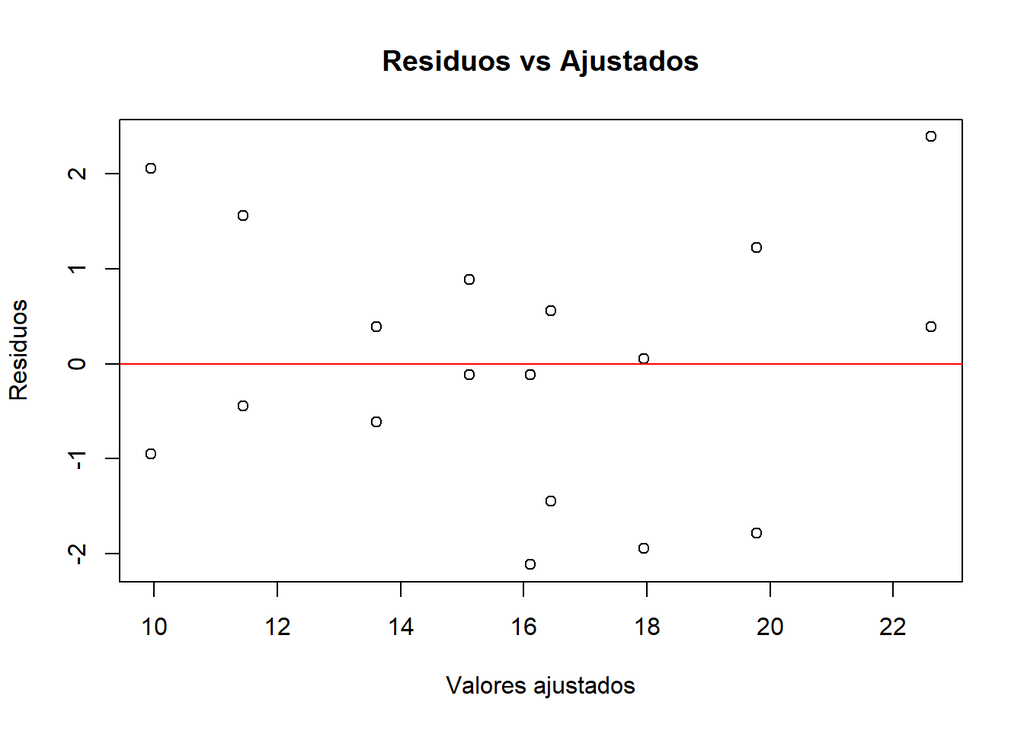

Se observa una distribución *aleatoria* en torno al valor esperado (0).  
- Normalidad

```
##
##  Shapiro-Wilk normality test
##
## data:  modelo_2$residuals
## W = 0.97156, p-value = 0.8265
```

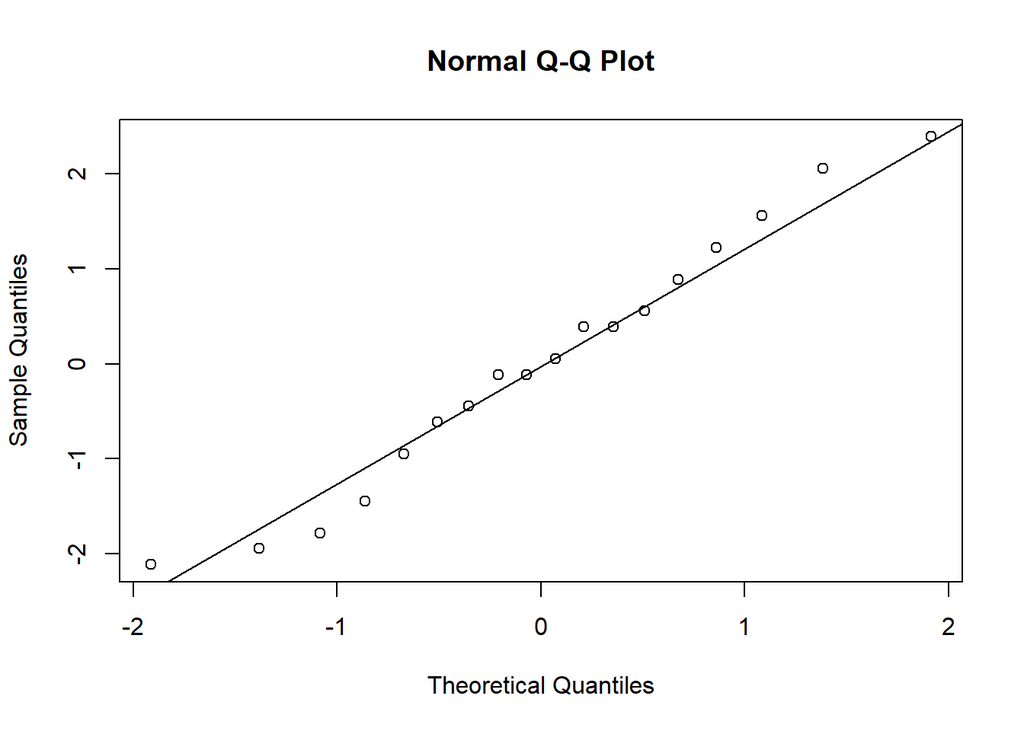

Debido a que el p-value>0.05, no rechazamos la hipótesis de normalidad.

- Independencia  
  Podemos asumir independencia porque la asignación del tratamiento fue aleatorizada. Análisis de comparaciones múltiples

Entonces, revisando la salida de R podemos representar al modelo como:

```
##
## Call:
## aov.default(formula = Respuesta ~ Temperatura + Porcentaje, data = rendimiento)
##
## Residuals:
##      Min       1Q   Median       3Q      Max
## -2.11111 -0.86111 -0.02778  0.80556  2.38889
##
## Coefficients:
##               Estimate Std. Error t value Pr(>|t|)
## (Intercept)    16.1111     0.8036  20.049 3.68e-11 ***
## Temperatura50  -4.6667     0.8803  -5.301 0.000144 ***
## Temperatura75  -6.1667     0.8803  -7.005 9.27e-06 ***
## Porcentaje60    3.6667     0.8803   4.165 0.001109 **
## Porcentaje80    6.5000     0.8803   7.384 5.32e-06 ***
## ---
## Signif. codes:  0 '***' 0.001 '**' 0.01 '*' 0.05 '.' 0.1 ' ' 1
##
## Residual standard error: 1.525 on 13 degrees of freedom
## Multiple R-squared:  0.8927, Adjusted R-squared:  0.8597
## F-statistic: 27.05 on 4 and 13 DF,  p-value: 3.392e-06
```

### d) Evaluación de efectos no lineales

|  | Res.Df | RSS | Df | Sum of Sq | F | Pr(>F) |
| --- | --- | --- | --- | --- | --- | --- |
| 1 | 15 | 89.69444 | NA | NA | NA | NA |
| 2 | 13 | 30.22222 | 2 | 59.47222 | 12.7909 | 0.0008494651 |

Podemos concluir que hay evidencia de efectos no lineales.

### e) Análisis de la combinación de Temperatura y Porcentaje que minimiza la diferencia entre el Rendimiento teórico y el observado

```
##  Temperatura Porcentaje emmean    SE df lower.CL upper.CL
##  100         40          16.11 0.804 13    14.38     17.8
##  50          40          11.44 0.804 13     9.71     13.2
##  75          40           9.94 0.804 13     8.21     11.7
##  100         60          19.78 0.804 13    18.04     21.5
##  50          60          15.11 0.804 13    13.38     16.8
##  75          60          13.61 0.804 13    11.88     15.3
##  100         80          22.61 0.804 13    20.88     24.3
##  50          80          17.94 0.804 13    16.21     19.7
##  75          80          16.44 0.804 13    14.71     18.2
##
## Confidence level used: 0.95
```

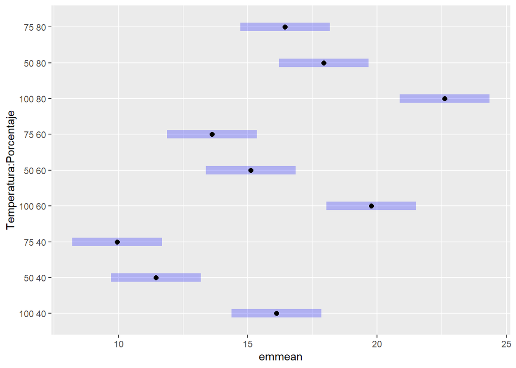

Concluimos que la combinación de 75ºC de temperatura y un 40% del compuesto B minimiza la diferencia entre el teórico y el observado.

# Práctica 4

## Ejercicio 3

Con referencia al artículo: Influencia del síndrome de Gilbert en los valores de bilirrubina sérica y presencia de litiasis vesicular en pacientes con hemólisis crónica congénita,

### a) ¿Cuál o cuáles variables se estudiaron en este trabajo?

Variables estudiadas en el trabajo presentado:

- Edad
- Bilirrubina total
- Nivel de hemoglobina
- Nivel de reticulocitos
- Presencia de litiasis vesicular

### b) Defina los distintos tratamientos considerados.

Los tratamientos considerados corresponden a variantes genotípicas de la región A(TA)nTAA del gen UCGT1A1:

- Genotipo TA*7/TA*7
- Genotipo TA*6/TA*7
- Genotipo TA*6/TA*6

### d) ¿Cuál fue la conclusión a la que se llegó mediante el test de Kruskal-Wallis?

No se encontraron diferencias estadísticamente significativas en los valores de hemoglobina, recuento de reticulocitos ni edad entre los tres grupos de pacientes, sugiriendo un grado de hemólisis similar en todos los grupos.

### f) Comente los resultados finales.

Los autores observan que los tres grupos de pacientes presentan niveles similares de hemólisis, con diferencias según el genotipo en los niveles de bilirrubina, y diferencias significativas también en la presencia de litiasis vesicular. De esta forma, concluyen que la identificación del síndrome de Gilbert puede ser importante para el pronóstico y plan médico de pacientes con hemólisis ligera o moderada.

# Práctica 5

## Ejercicio 3

En disciplinas como la Ecología o la Biología de la Conservación, uno de los problemas comunes es la identificación de los factores que influyen en variables como la riqueza de una especie, medida en este caso como el número de individuos presentes en un área determinada. En un estudio sobre la población de un parásito, se registró el logaritmo del recuento de parásitos de dicha especie en 15 localizaciones con diversas condiciones ambientales. Como variables explicativas se consideraron la temperatura (x1, en °C) y el porcentaje de humedad (x2).

Los datos obtenidos se encuentran en el archivo “parasito.txt”.

1. Realice el ajuste del modelo de regresión lineal múltiple incluyendo las 2 variables explicativas como variables regresoras y escriba la función de regresión estimada.
2. Ensaye la significación global de la regresión.
3. Realice las pruebas de hipótesis que le permitan evaluar: i. Si el coeficiente de regresión β1 es igual a cero. ii. Si el coeficiente de regresión β2 es igual a cero.
4. Evalúe la adecuación del modelo propuesto a través del valor de R2 y del análisis de residuos.
5. Ajuste el modelo Y = 𝛽<sub>0</sub> + 𝛽<sub>1</sub>x<sub>1</sub>+ ε. Utilice la información del modelo para probar la significación de la variable predictora Humedad con un test F. Ayuda: revisar test de significación para subconjuntos. ¿Coincide el resultado con el obtenido en el punto c? Justificar.

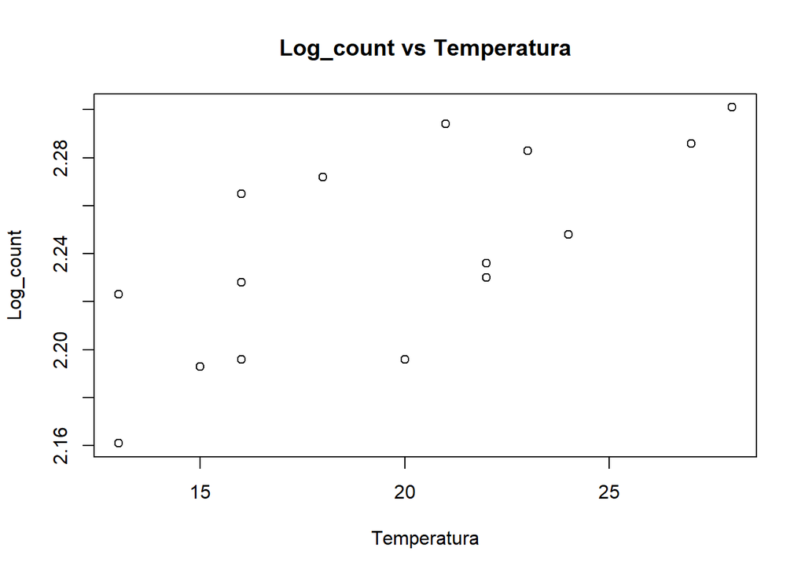

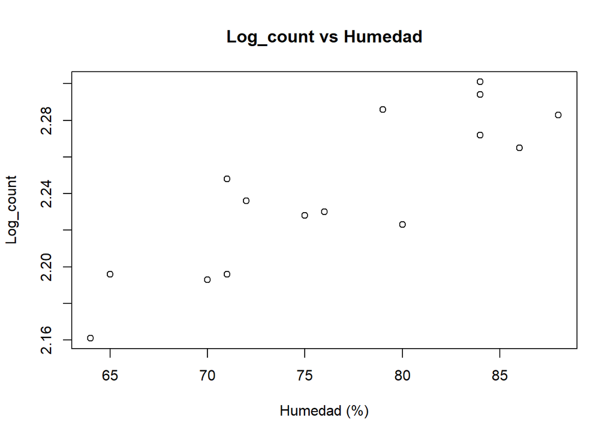

```
## [1] "Correlación entre temperatura y humedad"
```

```
## [1] 0.3559092
```

### a) Ajuste del modelo de regresión

```
##
## Call:
## lm.default(formula = log_count ~ temperatura + humedad, data = parasito)
##
## Coefficients:
## (Intercept)  temperatura      humedad
##    1.865286     0.003935     0.003896
```

Función de regresión estimada:

log_count = 𝛽<sub>0 +</sub> 𝛽<sub>1</sub> temperatura + 𝛽<sub>2</sub> humedad

log_count = 1.865 + 0.00393 temperatura + 0.00390 humedad

### b) Ensayo de significación global de la regresión

$H_0)$ $\beta_1= \beta_2 =0$

$H_1)$ Al menos un $\beta_j \neq 0$; $j = 1;2$

```
##
## Call:
## lm.default(formula = log_count ~ temperatura + humedad, data = parasito)
##
## Residuals:
##       Min        1Q    Median        3Q       Max
## -0.024559 -0.004913  0.001746  0.008133  0.018865
##
## Coefficients:
##              Estimate Std. Error t value Pr(>|t|)
## (Intercept) 1.8652859  0.0358139  52.083 1.65e-15 ***
## temperatura 0.0039345  0.0007980   4.930 0.000348 ***
## humedad     0.0038955  0.0004971   7.836 4.65e-06 ***
## ---
## Signif. codes:  0 '***' 0.001 '**' 0.01 '*' 0.05 '.' 0.1 ' ' 1
##
## Residual standard error: 0.01333 on 12 degrees of freedom
## Multiple R-squared:  0.9153, Adjusted R-squared:  0.9012
## F-statistic: 64.81 on 2 and 12 DF,  p-value: 3.7e-07
```

F = 64.81; p-value = 3.7 e-07 < 0.05 ⇒ Se rechaza H<sub>0</sub>

Con un nivel de significación del 5%, se concluye que al menos uno de los coeficientes de regresión es significativamente distinto de cero.

### c) Ensayo de significación individual de la regresión

$H_0)$ $\beta_1=0$

$H_1)$ $\beta_1\neq0$

p-value = 0.000348 < 0.05 ⇒ Se rechaza H<sub>0</sub>

Con un nivel de significación del 5%, el coeficiente de regresión para la temperatura es significativamente distinto de cero.

$H_0)$ $\beta_2=0$

$H_1)$ $\beta_2\neq0$

p-value = 4.65e-06 < 0.05 ⇒ Se rrechaza H<sub>0</sub>

Con un nivel de significación del 5%, el coeficiente de regresión para la humedad es significativamente distinto de cero.

### d) Evaluación del modelo

```
##
##  Shapiro-Wilk normality test
##
## data:  residuos
## W = 0.96329, p-value = 0.7493
```

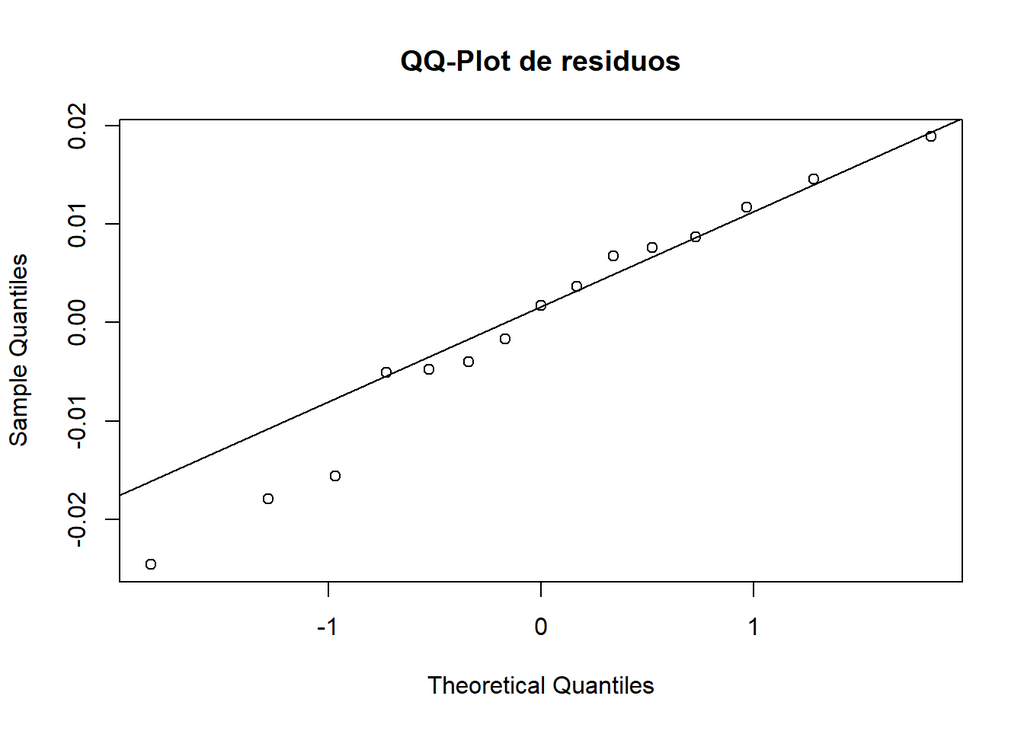

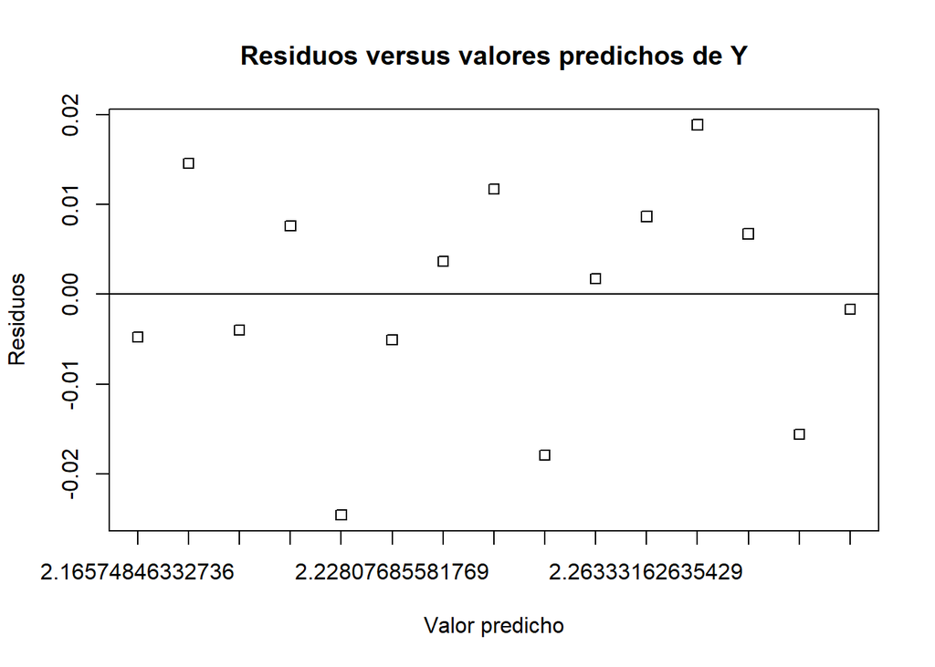

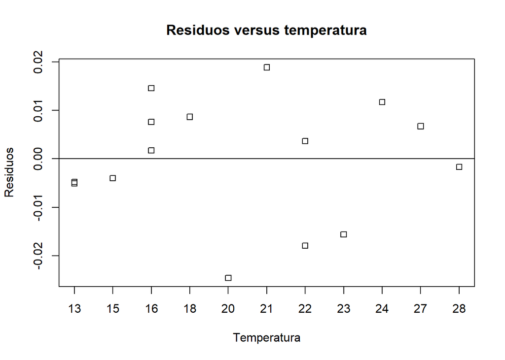

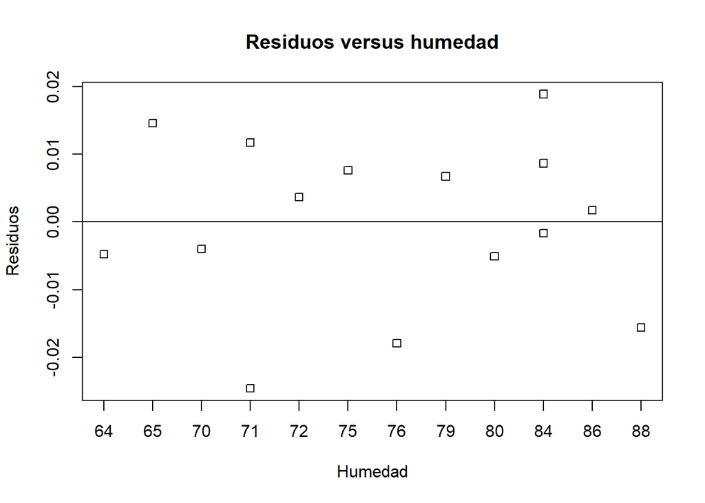

R<sup>2</sup> = 0.9153

R<sup>2</sup> ajustado = 0.9012

p-value test de shapiro para residuos = 0.7493

El análisis de los residuos permite verificar el supuesto de normalidad de los errores aleatorios. Adicionalmente, observando los gráficos de residuos vs valores predichos y los valores de las variables, se observan resultados compatibles con el supuesto de homocedasticidad.

Con respecto a los valores de R<sup>2</sup> , se observa que aproximadamente el 90% de la variabilidad observada en el logaritmo del recuento de parásitos es explicada por el modelo de regresión que contempla la variabilidad de tempratura y humedad.

### e) Ajuste del modelo para la variable predictora humedad

```
##
## Call:
## lm.default(formula = log_count ~ temperatura, data = parasito)
##
## Residuals:
##       Min        1Q    Median        3Q       Max
## -0.047264 -0.021264 -0.000385  0.022056  0.046377
##
## Coefficients:
##             Estimate Std. Error t value Pr(>|t|)
## (Intercept) 2.120060   0.035684  59.411   <2e-16 ***
## temperatura 0.006160   0.001772   3.476   0.0041 **
## ---
## Signif. codes:  0 '***' 0.001 '**' 0.01 '*' 0.05 '.' 0.1 ' ' 1
##
## Residual standard error: 0.03168 on 13 degrees of freedom
## Multiple R-squared:  0.4817, Adjusted R-squared:  0.4419
## F-statistic: 12.08 on 1 and 13 DF,  p-value: 0.004097
```

|  | Res.Df | RSS | Df | Sum of Sq | F | Pr(>F) |
| --- | --- | --- | --- | --- | --- | --- |
| 1 | 13 | 0.013048198 | NA | NA | NA | NA |
| 2 | 12 | 0.002133143 | 1 | 0.01091505 | 61.40267 | 4.645145e-06 |

La comparación de los modelos mediante ANOVA tiene un valor de F de 61.403 con un p-value de 4.645e-06. Esto indica que contemplar la variable humedad dentro del modelo genera un cambio significativo en el ajuste.

El resultado del test F coincide con los resultados observados en el punto c. Esto ocurre porque matemáticamente los valores coinciden cuando en el subcojunto analizado hay un solo predictor.